# Question

In a deck of strange cards, there are 620 cards. Each card has an image and a color.

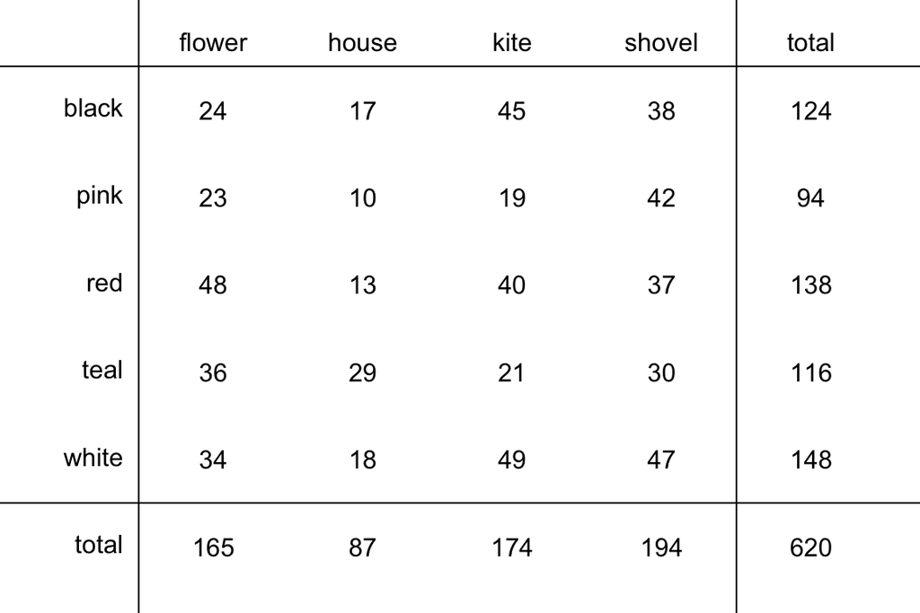

1. Between a flower and a house, which is more likely to be a pink? ##ANSWER1##
2. What is the probability a random card is either a house or white (or both)? ##ANSWER2##
3. What is the probability a random card is a shovel given it is red? ##ANSWER3##
4. What is the probability a random card is both a shovel and black? ##ANSWER4##
5. What is the probability a random card is red given it is a flower? ##ANSWER5##
6. What is the probability a random card is a shovel? ##ANSWER6##
7. What is the probability a random card is white? ##ANSWER7##

## Answerlist

- A flower.
- A house.
- 0.11
- 0.24
- 0.35
- 0.40
- 0.27
- 0.30
- 0.39
- 0.42
- 0.06
- 0.13
- 0.17
- 0.22
- 0.11
- 0.19
- 0.29
- 0.67
- 0.22
- 0.31
- 0.45
- 0.72
- 0.24
- 0.42
- 0.51
- 0.70

# Solution

[video](https://vimeo.com/531915456)

The key logical terms are “[and](https://en.wikipedia.org/wiki/Logical_conjunction)”, “[or](https://en.wikipedia.org/wiki/Logical_disjunction)”, and “[given](https://en.wikipedia.org/wiki/Conditional_probability)”. Notice that I am using “given” as a shorter version of “under the condition”.

1. $\mathbb{P}[\text{pink given flower}] = 0.14$ and $\mathbb{P}[\text{pink given house}] = 0.11$, so a flower is more likely to be pink than a house is.
2. $\mathbb{P}[\text{house or white}]=\frac{87+148-18}{620}=0.35$
3. $\mathbb{P}[\text{shovel given red}]=\frac{37}{138}=0.27$
4. $\mathbb{P}[\text{shovel and black}]=\frac{38}{620}=0.06$
5. $\mathbb{P}[\text{red given flower}]=\frac{48}{165}=0.29$
6. $\mathbb{P}[\text{shovel}]=\frac{194}{620}=0.31$
7. $\mathbb{P}[\text{white}]=\frac{148}{620}=0.24$

# Meta-information

extype: cloze exsolution: 10|0010|1000|1000|0010|0100|1000 exclozetype: schoice|schoice|schoice|schoice|schoice|schoice|schoice exname: Cards_probabilities_shuffled